[figure not shown]

# Reading, Cleaning, and Visualizing the real world project repository of Scala

Presented By:

**SIDDHARTH VERMA**

Under the Guidence of:

Prof. Sachin Patel

## Problem Statement

- We are going to clean up and visualize the real world project, data receives from version control system (Git) and also from project hosting site (GitHub).
- By using Jupyter notebook and the concepts of Data Science, we will find out who has had the most influence on its development and who are the experts.
- We are using the data from 2011-2018 of GitHub (A project hosting site).

## Technology, System and Software Requirement

[figure not shown]

## Introduction to Data Analysis

**Data Analysis** is a process of inspecting, cleansing, transforming, and modeling data with the goal of discovering, informing conclusions and supporting decision – making.

[figure not shown]

## What is GitHub?

**GitHub** is a project hosting site. Millions of developers and companies build, ship, and maintain their software on GitHub. GitHub is the largest and most advanced development platform in the world.

[figure not shown]

## Data used for analysis.

- The data set used is extracted from GitHub, which is a project hosting site.
- The data set is comprised of three files which are in .csv (Comma-seperated values) format.
- The files which store data is arround 4-5 MegaBytes.
- The data used is a **Structured data**, which is highly specific and is stored in a predefined format.

## Essential Details of Data's.

```python
# pandas imported
import pandas as pd
```

# **Pandas**

Pandas or Python Pandas is Python’s library for data analysis. Pandas has derived its name from **“panel data system”**, which is an ecometrics term for multi-dimensional, structured data sets. Today, Pandas has become a popular choice for data analysis. As you must be aware of that data analysis refers to process of evaluating big data sets using analytical and statistical tools so as to discover useful information and conclusions to support business decision-making. Pandas makes available various tools for data analysis and makes it a simple and easy process as compared to. other available tools.

```python
data1 = pd.read_csv(r'Data/pulls_2011-2013.csv')
# file pulls_2011-2013 is imported in object data1
data1.head()
```

|  | pid | user | date |
| --- | --- | --- | --- |
| 0 | 11166973 | VladimirNik | 2013-12-31T23:10:55Z |
| 1 | 11161892 | Ichoran | 2013-12-31T16:55:47Z |
| 2 | 11153894 | Ichoran | 2013-12-31T02:41:13Z |
| 3 | 11151917 | rklaehn | 2013-12-30T23:45:47Z |
| 4 | 11131244 | qerub | 2013-12-29T17:21:01Z |

```python
data2 = pd.read_csv(r'Data/pulls_2014-2018.csv')
# file pulls_2014-2018 is imported in object data2
data2.head()
```

|  | pid | user | date |
| --- | --- | --- | --- |
| 0 | 163314316 | hrhino | 2018-01-16T23:29:16Z |
| 1 | 163061502 | joroKr21 | 2018-01-15T23:44:52Z |
| 2 | 163057333 | mkeskells | 2018-01-15T23:05:06Z |
| 3 | 162985594 | lrytz | 2018-01-15T15:52:39Z |
| 4 | 162838837 | zuvizudar | 2018-01-14T19:16:16Z |

```python
data3 = pd.read_csv(r'Data/pull_files.csv')
# file pull_files is imported in object data3
data3.head()
```

|  | pid | file |
| --- | --- | --- |
| 0 | 163314316 | test/files/pos/t5638/Among.java |
| 1 | 163314316 | test/files/pos/t5638/Usage.scala |
| 2 | 163314316 | test/files/pos/t9291.scala |
| 3 | 163314316 | test/files/run/t8348.check |
| 4 | 163314316 | test/files/run/t8348/TableColumn.java |

## Preparing the data

So, we just imported the data as `data1`, `data2` and `data3` then, we will need to combine the data from the two separate pull DataFrames i.e., `data1` and `data2`.

```python
full_data = data1.append(data2, ignore_index = True)
# New object full_data stores data from 2011 to 2018
full_data.head()
```

|  | pid | user | date |
| --- | --- | --- | --- |
| 0 | 11166973 | VladimirNik | 2013-12-31T23:10:55Z |
| 1 | 11161892 | Ichoran | 2013-12-31T16:55:47Z |
| 2 | 11153894 | Ichoran | 2013-12-31T02:41:13Z |
| 3 | 11151917 | rklaehn | 2013-12-30T23:45:47Z |
| 4 | 11131244 | qerub | 2013-12-29T17:21:01Z |

## Merging the DataFrames

The data extracted comes in two separate files i.e., `data3` and `full_data`. Merging the two DataFrames make it easier for us to analyze the data in next tasks or analysing.

```python
# merging the data3 in full_data on the 'pid'
new_data = full_data.merge(data3, on = 'pid')
new_data.head()
```

|  | pid | user | date | file |
| --- | --- | --- | --- | --- |
| 0 | 11166973 | VladimirNik | 2013-12-31T23:10:55Z | src/reflect/scala/reflect/api/Printers.scala |
| 1 | 11166973 | VladimirNik | 2013-12-31T23:10:55Z | src/reflect/scala/reflect/internal/Printers.scala |
| 2 | 11166973 | VladimirNik | 2013-12-31T23:10:55Z | test/files/run/reify_ann3.check |
| 3 | 11166973 | VladimirNik | 2013-12-31T23:10:55Z | test/junit/scala/reflect/internal/PrintersTest... |
| 4 | 11161892 | Ichoran | 2013-12-31T16:55:47Z | src/library/scala/collection/mutable/ArrayOps.... |

## Cleaning the data

The raw data extracted from GitHub contains dates in the **ISO8601**(Representation of dates and times is an international standard covering the exchange of date- and time-related data) format. However, `pandas` imports them as regular strings. To make our analysis easier, we need to convert the strings into Python's `DateTime` objects. `DateTime` objects have the important property that they can be compared and sorted.

The GitHub pull request times are all in UTC (also known as Coordinated Universal Time). To make comparisons easy, we should convert all times to UTC.

```python
# Converting date and time in UTC format
new_data['date']=pd.to_datetime(new_data['date'],utc=True)
new_data.head()
```

|  | pid | user | date | file |
| --- | --- | --- | --- | --- |
| 0 | 11166973 | VladimirNik | 2013-12-31 23:10:55+00:00 | src/reflect/scala/reflect/api/Printers.scala |
| 1 | 11166973 | VladimirNik | 2013-12-31 23:10:55+00:00 | src/reflect/scala/reflect/internal/Printers.scala |
| 2 | 11166973 | VladimirNik | 2013-12-31 23:10:55+00:00 | test/files/run/reify_ann3.check |
| 3 | 11166973 | VladimirNik | 2013-12-31 23:10:55+00:00 | test/junit/scala/reflect/internal/PrintersTest... |
| 4 | 11161892 | Ichoran | 2013-12-31 16:55:47+00:00 | src/library/scala/collection/mutable/ArrayOps.... |

```python
# Extracting month in new column 'month'
new_data['month']=new_data['date'].dt.month
new_data.head()
```

|  | pid | user | date | file | month |
| --- | --- | --- | --- | --- | --- |
| 0 | 11166973 | VladimirNik | 2013-12-31 23:10:55+00:00 | src/reflect/scala/reflect/api/Printers.scala | 12 |
| 1 | 11166973 | VladimirNik | 2013-12-31 23:10:55+00:00 | src/reflect/scala/reflect/internal/Printers.scala | 12 |
| 2 | 11166973 | VladimirNik | 2013-12-31 23:10:55+00:00 | test/files/run/reify_ann3.check | 12 |
| 3 | 11166973 | VladimirNik | 2013-12-31 23:10:55+00:00 | test/junit/scala/reflect/internal/PrintersTest... | 12 |
| 4 | 11161892 | Ichoran | 2013-12-31 16:55:47+00:00 | src/library/scala/collection/mutable/ArrayOps.... | 12 |

```python
# Extracting year in new column 'year'
new_data['year']=new_data['date'].dt.year
new_data.head()
```

|  | pid | user | date | file | month | year |
| --- | --- | --- | --- | --- | --- | --- |
| 0 | 11166973 | VladimirNik | 2013-12-31 23:10:55+00:00 | src/reflect/scala/reflect/api/Printers.scala | 12 | 2013 |
| 1 | 11166973 | VladimirNik | 2013-12-31 23:10:55+00:00 | src/reflect/scala/reflect/internal/Printers.scala | 12 | 2013 |
| 2 | 11166973 | VladimirNik | 2013-12-31 23:10:55+00:00 | test/files/run/reify_ann3.check | 12 | 2013 |
| 3 | 11166973 | VladimirNik | 2013-12-31 23:10:55+00:00 | test/junit/scala/reflect/internal/PrintersTest... | 12 | 2013 |
| 4 | 11161892 | Ichoran | 2013-12-31 16:55:47+00:00 | src/library/scala/collection/mutable/ArrayOps.... | 12 | 2013 |

## Grouping the data

We will calculate the number of pull requests submitted each (calendar) month during the project's lifetime. For this the data will grouped on `year` and `month` to perform better visualization.

```python
# object count is created that store repository makes per month
count=new_data.groupby(['month','year'])['pid'].count()
count
```

```
month  year
1      2012     489
       2013    3717
       2014    1140
       2015     732
       2016     640
               ...
12     2013    1692
       2014    1001
       2015     616
       2016     468
       2017     224
Name: pid, Length: 74, dtype: int64
```

# **Data Visualization**

**Data visualization** basically refers to the graphical or visual representation of information and data using visual elements like `charts`, `graphs`, and `maps` etc. Data visualization is immensely useful in decision making. Data visualization unveils patterns, trends, outliers, correlations etc. in the data, and thereby helps decision makers understand the meaning of data to drive **business decisions**.****

[figure not shown]

```python
# Matplotlib imported
import matplotlib.pyplot as plt
```

# Matplotlib

For data visualization in Python, the **Matplotlib** library’s **Pyplot** interface is used.

The matplotlib is a Python library that provides many interfaces and functionality for `2D-graphics` similar to **MATLAB’s** in various forms. In short, you can call matplotlib as a high quality plotting library of Python. It provides both a very quick way to visualize data from Python and publication-quality figures in many formats. The matplotlib library offers many different named collections of methods; PyPlot is one such interface. PyPlot is a collection of methods within matplotlib which allows user to construct 2D plots easily and interactively. PyPlot essentially reproduces plotting functions and behavior of MATLAB.

The object `count` stores data as repository per month between many year's. Using that object we are going to see visual representation of creating reository in all subject (scala, java, txt, etc) with respect to months and years.

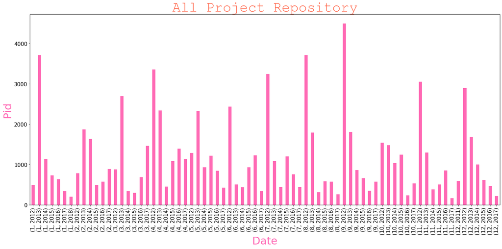

```python
# using plot function we are using to represent all stuf of object count
count.plot(kind='bar',figsize=(24,10),color='HotPink',fontsize=15)

# Title declared for object count
plt.title('All Project Repository', fontsize=40, color="Tomato", fontname = "Courier New")

# labelling the chart
plt.xlabel('Date', fontsize=30, color="HotPink")
plt.ylabel('Pid', fontsize=30, color="HotPink")
```

## Data Minning

We have seen the visual representation of all subject, but we are here to find who is expert in **scala** and hence from `new_data` we are going to extract data for only user's who work in scala most.

```python
# creating new object raw_data which will store the data of those users who only work in scala
raw_data = new_data[new_data['file'] == [_ if _.endswith('.scala') else 0 for _ in new_data['file']]]

# arranging index of the data
raw_data.reset_index(drop = True).head()
```

|  | pid | user | date | file | month | year |
| --- | --- | --- | --- | --- | --- | --- |
| 0 | 11166973 | VladimirNik | 2013-12-31 23:10:55+00:00 | src/reflect/scala/reflect/api/Printers.scala | 12 | 2013 |
| 1 | 11166973 | VladimirNik | 2013-12-31 23:10:55+00:00 | src/reflect/scala/reflect/internal/Printers.scala | 12 | 2013 |
| 2 | 11166973 | VladimirNik | 2013-12-31 23:10:55+00:00 | test/junit/scala/reflect/internal/PrintersTest... | 12 | 2013 |
| 3 | 11161892 | Ichoran | 2013-12-31 16:55:47+00:00 | src/library/scala/collection/mutable/ArrayOps.... | 12 | 2013 |
| 4 | 11153894 | Ichoran | 2013-12-31 02:41:13+00:00 | src/library/scala/collection/immutable/Numeric... | 12 | 2013 |

## Prepare for Visualization

We will calculate the number of pull requests submitted each (calendar) month during the project's lifetime. But this time the data will grouped on `year` and `month` only for `.scala` file and count repository created in those months of each year to perform visualization.

```python
# object count is created that store repository makes per month of .scala file
counts_again = raw_data.groupby(['month', 'year'])['pid'].count()
counts_again
```

```
month  year
1      2012     430
       2013    2581
       2014     902
       2015     568
       2016     435
               ...
12     2013    1162
       2014     929
       2015     435
       2016     328
       2017     173
Name: pid, Length: 74, dtype: int64
```

The object `count_again` stores data as repository per month between many year's. Using that object again we are going to see visual representation of creating reository but this time only for scala file with respect to months and years.

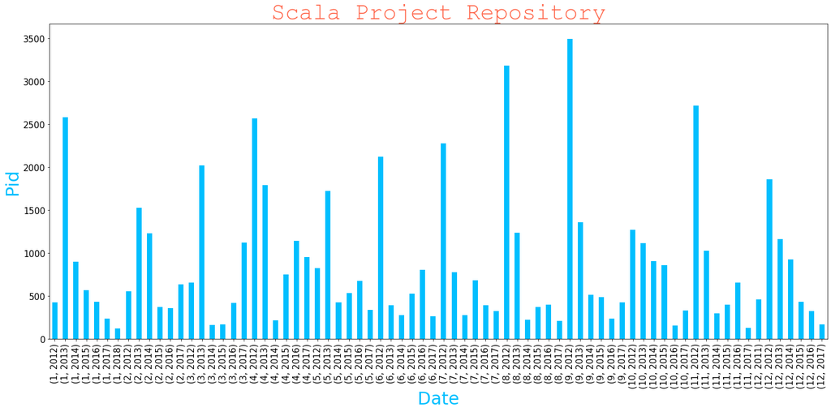

```python
# using plot function we are using to represent all stuf of object counts_again
counts_again.plot(kind='bar',figsize=(24,10), color='DeepSkyBlue',fontsize=15)

# Title declared for object counts_again
plt.title('Scala Project Repository', fontsize=40, color="Tomato", fontname = "Courier New")

# labelling the chart
plt.xlabel('Date', fontsize=30, color="DeepSkyBlue")
plt.ylabel('Pid', fontsize=30, color="DeepSkyBlue")
```

## Extracting Top 5 Experts of Scala

```python
# Object scala_user stores number of repository created by user's
scala_user = new_data.groupby('user')['pid'].count()
scala_user
```

```
user
0xmohit           2
193s              4
2m               20
4.00E+06         22
AlexeyIvanov8     2
                 ..
yinxusen          1
yllan             4
ziggystar        22
zsxwing           6
zuvizudar         1
Name: pid, Length: 464, dtype: int64
```

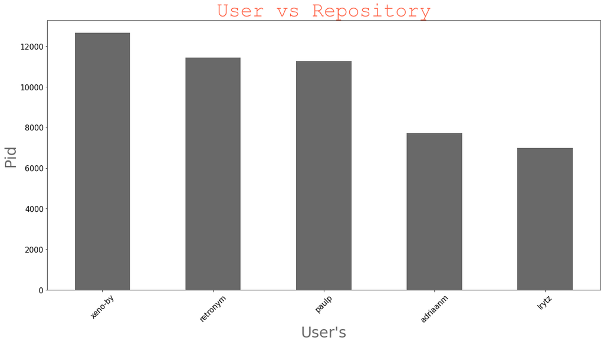

```python
# the object top_5 stores top 5 user of scala repository
top_5 = scala_user.nlargest(5)

# using plot function we are using to represent all stuf of object top_5
top_5.plot(kind='bar', fontsize='15', figsize=(20, 10), color="DimGray")

# Title declared for object counts_again
plt.title("User vs Repository", fontsize=40, color="Tomato", fontname = "Courier New")

# labelling the chart
plt.xticks(rotation=45)
plt.xlabel("User's", fontsize='30', color="DimGray")
plt.ylabel("Pid", fontsize='30', color="DimGray")
```

## Analysing Only One User

```python
# created object users which store the name of 5 experts
users = ['xeno-by', 'retronym', 'paulp', 'adriaanm', 'lrytz']

# final_data is the data which only only contain details of experts
final_data = raw_data[raw_data['user'].isin(users)]
final_data.reset_index(drop = True).head()
```

|  | pid | user | date | file | month | year |
| --- | --- | --- | --- | --- | --- | --- |
| 0 | 11126653 | xeno-by | 2013-12-28 19:39:23+00:00 | src/reflect/scala/reflect/internal/Mirrors.scala | 12 | 2013 |
| 1 | 11126653 | xeno-by | 2013-12-28 19:39:23+00:00 | test/junit/scala/reflect/internal/MirrorsTest.... | 12 | 2013 |
| 2 | 11121557 | xeno-by | 2013-12-27 23:50:56+00:00 | test/files/neg/t8104a/Macros_1.scala | 12 | 2013 |
| 3 | 11121557 | xeno-by | 2013-12-27 23:50:56+00:00 | test/files/neg/t8104a/Test_2.scala | 12 | 2013 |
| 4 | 11121557 | xeno-by | 2013-12-27 23:50:56+00:00 | test/files/neg/t8104b/Macros_1.scala | 12 | 2013 |

Now we are going to visualize `xeno-by` progress per year. That how much he/she was growed up per year.

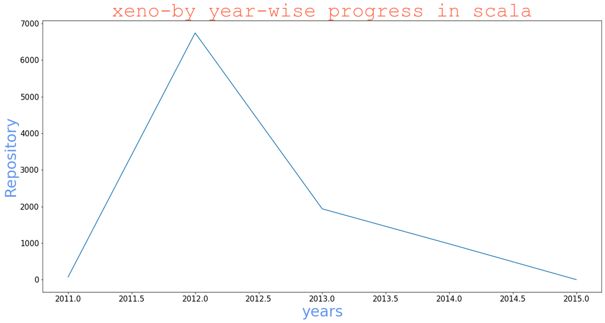

```python
# object count1 stores data of 'xeno-by' with number of repository created per year in scala
count1 = final_data[final_data['user'] == 'xeno-by'].groupby('year')['pid'].count()

# using plot function we are using to represent all stuf of object count1
count1.plot(kind = 'line', figsize = (20, 10), fontsize = 15)

# Title declared for object counts_again
plt.title("xeno-by year-wise progress in scala", fontsize = 40, color = "Tomato", fontname = "Courier New")

# labelling the chart
plt.xlabel('years', fontsize = 30, color = "CornflowerBlue")
plt.ylabel('Repository', fontsize = 30, color = "CornflowerBlue")
```

## Preparing Data for all experts process per Year

```python
final = final_data.groupby([final_data['user'], final_data['date'].dt.year]).agg({'pid':'count'}).reset_index()
final
```

|  | user | date | pid |
| --- | --- | --- | --- |
| 0 | adriaanm | 2011 | 12 |
| 1 | adriaanm | 2012 | 1258 |
| 2 | adriaanm | 2013 | 2030 |
| 3 | adriaanm | 2014 | 389 |
| 4 | adriaanm | 2015 | 570 |
| 5 | adriaanm | 2016 | 540 |
| 6 | adriaanm | 2017 | 498 |
| 7 | lrytz | 2012 | 196 |
| 8 | lrytz | 2013 | 75 |
| 9 | lrytz | 2014 | 530 |
| 10 | lrytz | 2015 | 1868 |
| 11 | lrytz | 2016 | 702 |
| 12 | lrytz | 2017 | 1019 |
| 13 | lrytz | 2018 | 3 |
| 14 | paulp | 2012 | 5712 |
| 15 | paulp | 2013 | 2981 |
| 16 | paulp | 2014 | 41 |
| 17 | paulp | 2016 | 7 |
| 18 | paulp | 2017 | 4 |
| 19 | retronym | 2012 | 554 |
| 20 | retronym | 2013 | 3234 |
| 21 | retronym | 2014 | 1599 |
| 22 | retronym | 2015 | 1226 |
| 23 | retronym | 2016 | 894 |
| 24 | retronym | 2017 | 887 |
| 25 | xeno-by | 2011 | 79 |
| 26 | xeno-by | 2012 | 6743 |
| 27 | xeno-by | 2013 | 1938 |
| 28 | xeno-by | 2014 | 981 |
| 29 | xeno-by | 2015 | 5 |